# report

> Seliverstov Mark  
> Summer semester 2022/2023  
> Probability and Statistics 1, NMAI059

> Were used:
> - Python 3.11 with libraries: pandas, matplotlib, scipy
> - [Source of data](https://www.kaggle.com/datasets/uom190346a/sleep-health-and-lifestyle-dataset?resource=download)

# Statistical Analysis Report

## Introduction

This report presents a statistical analysis of a dataset containing information about individuals health-related factors. The dataset includes variables such as `gender, age, occupation, sleep duration, quality of sleep, physical activity level, stress level, BMI category, blood pressure, heart rate, daily steps, and the presence of sleep disorders`. The purpose of this analysis is to explore relationships, patterns, and trends within the data to gain insights into factors that may impact individuals' health and well-being.

The dataset was collected from a diverse group of individuals, each identified by a unique `Person ID`. The variables in the dataset encompass a wide range of factors that can influence an individual's health, including sleep patterns, physical activity, stress levels, and more. By applying statistical techniques and data visualization, we aim to answer several research questions and hypotheses, such as:

- Is there a correlation between sleep duration and daily steps taken?
- Hypothesis on the difference in sleep duration between genders.
- Hypothesis on the relationship between the physical activity level and sleep quality.

## Data Description

Note: The dataset is anonymized, the analysis is purely for academic and research purposes.  
Source of data: https://www.kaggle.com/datasets/uom190346a/sleep-health-and-lifestyle-dataset?resource=download

### Dataset Overview

The dataset used in this analysis comprises health and lifestyle data for a sample of individuals. Before delving into the statistical analysis, let's provide an overview of the dataset:

### Dataset Columns:

- **Person ID**: An identifier for each individual.
- **Gender**: The gender of the person (Male/Female).
- **Age**: The age of the person in years.
- **Occupation**: The occupation or profession of the person.
- **Sleep Duration (hours)**: The number of hours the person sleeps per day.
- **Quality of Sleep (scale: 1-10)**: A subjective rating of the quality of sleep, ranging from 1 to 10.
- **Physical Activity Level (minutes/day)**: The number of minutes the person engages in physical activity daily.
- **Stress Level (scale: 1-10)**: A subjective rating of the stress level experienced by the person, ranging from 1 to 10.
- **BMI Category**: The BMI category of the person (e.g., Underweight, Normal, Overweight).
- **Blood Pressure (systolic/diastolic)**: The blood pressure measurement of the person, indicated as systolic pressure over diastolic pressure.
- **Heart Rate (bpm)**: The resting heart rate of the person in beats per minute.
- **Daily Steps**: The number of steps the person takes per day.
- **Sleep Disorder**: The presence or absence of a sleep disorder in the person (None, Insomnia, Sleep Apnea).

#### Details about Sleep Disorder Column:

- **None:** The individual does not exhibit any specific sleep disorder.
- **Insomnia:** The individual experiences difficulty falling asleep or staying asleep, leading to inadequate or poor-quality sleep.
- **Sleep Apnea:** The individual suffers from pauses in breathing during sleep, resulting in disrupted sleep patterns and potential health risks.

## Descriptive Statistics:

```python
# Imports
import pandas as pd
import matplotlib.pyplot as plt
import scipy.stats as stats
```

```python
# Age
mean_age = df['Age'].mean()
median_age = df['Age'].median()
min_age = df['Age'].min()
max_age = df['Age'].max()

print("Age:")
print("Mean Age:", mean_age)
print("Median Age:", median_age)
print("Minimum Age:", min_age)
print("Maximum Age:", max_age)
```

```
Age:
Mean Age: 42.18449197860963
Median Age: 43.0
Minimum Age: 27
Maximum Age: 59
```

```python
# Sleep Duration
mean_sleep_duration = df['Sleep Duration'].mean()
median_sleep_duration = df['Sleep Duration'].median()
min_sleep_duration = df['Sleep Duration'].min()
max_sleep_duration = df['Sleep Duration'].max()

print("\nSleep Duration:")
print("Mean Sleep Duration (hours):", mean_sleep_duration)
print("Median Sleep Duration (hours):", median_sleep_duration)
print("Minimum Sleep Duration (hours):", min_sleep_duration)
print("Maximum Sleep Duration (hours):", max_sleep_duration)
```

```
Sleep Duration:
Mean Sleep Duration (hours): 7.132085561497325
Median Sleep Duration (hours): 7.2
Minimum Sleep Duration (hours): 5.8
Maximum Sleep Duration (hours): 8.5
```

```python
# Heart Rate
mean_heart_rate = df['Heart Rate'].mean()
median_heart_rate = df['Heart Rate'].median()
min_heart_rate = df['Heart Rate'].min()
max_heart_rate = df['Heart Rate'].max()

print("\nHeart Rate:")
print("Mean Heart Rate (bpm):", mean_heart_rate)
print("Median Heart Rate (bpm):", median_heart_rate)
print("Minimum Heart Rate (bpm):", min_heart_rate)
print("Maximum Heart Rate (bpm):", max_heart_rate)
```

```
Heart Rate:
Mean Heart Rate (bpm): 70.16577540106952
Median Heart Rate (bpm): 70.0
Minimum Heart Rate (bpm): 65
Maximum Heart Rate (bpm): 86
```

```python
# Daily Steps
mean_daily_steps = df['Daily Steps'].mean()
median_daily_steps = df['Daily Steps'].median()
min_daily_steps = df['Daily Steps'].min()
max_daily_steps = df['Daily Steps'].max()

print("\nDaily Steps:")
print("Mean Daily Steps:", mean_daily_steps)
print("Median Daily Steps:", median_daily_steps)
print("Minimum Daily Steps:", min_daily_steps)
print("Maximum Daily Steps:", max_daily_steps)
```

```
Daily Steps:
Mean Daily Steps: 6816.844919786096
Median Daily Steps: 7000.0
Minimum Daily Steps: 3000
Maximum Daily Steps: 10000
```

```python
# Measures of Dispersion
std_age = df['Age'].std()
range_age = max_age - min_age

print("\nMeasures of Dispersion:")
print("\nAge:")
print("Standard Deviation:", std_age)
print("Range:", range_age)

std_sleep_duration = df['Sleep Duration'].std()
range_sleep_duration = max_sleep_duration - min_sleep_duration

print("\nSleep Duration:")
print("Standard Deviation:", std_sleep_duration)
print("Range:", range_sleep_duration)

std_heart_rate = df['Heart Rate'].std()
range_heart_rate = max_heart_rate - min_heart_rate

print("\nHeart Rate:")
print("Standard Deviation:", std_heart_rate)
print("Range:", range_heart_rate)

std_daily_steps = df['Daily Steps'].std()
range_daily_steps = max_daily_steps - min_daily_steps

print("\nDaily Steps:")
print("Standard Deviation:", std_daily_steps)
print("Range:", range_daily_steps)
```

```
Measures of Dispersion:

Age:
Standard Deviation: 8.673133465547243
Range: 32

Sleep Duration:
Standard Deviation: 0.7956567308898189
Range: 2.7

Heart Rate:
Standard Deviation: 4.135675535112215
Range: 21

Daily Steps:
Standard Deviation: 1617.915679133636
Range: 7000
```

```python
# Correlations
correlation_sleep_steps = df['Sleep Duration'].corr(df['Daily Steps'])
correlation_stress_heart_rate = df['Stress Level'].corr(df['Heart Rate'])

print("\nCorrelations:")
print("Correlation between Sleep Duration and Daily Steps:", correlation_sleep_steps)
print("Correlation between Stress Level and Heart Rate:", correlation_stress_heart_rate)
```

```
Correlations:
Correlation between Sleep Duration and Daily Steps: -0.039532537675732865
Correlation between Stress Level and Heart Rate: 0.6700264629986925
```

# Data Visualization:

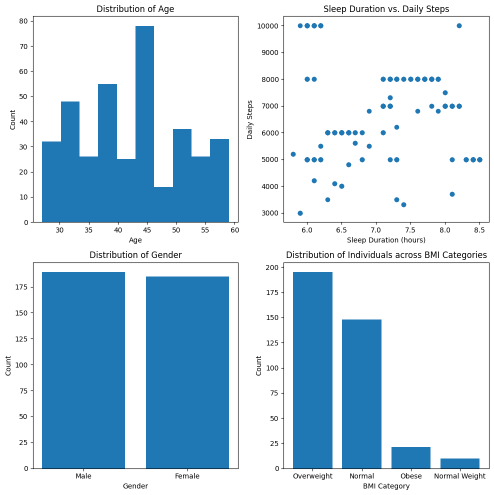

```python
# Create a figure with subplots
fig, axes = plt.subplots(2, 2, figsize=(10, 10))

# Histogram of Age
axes[0, 0].hist(df['Age'], bins=10)
axes[0, 0].set_title('Distribution of Age')
axes[0, 0].set_xlabel('Age')
axes[0, 0].set_ylabel('Count')

# Scatter plot of Sleep Duration vs. Daily Steps
axes[0, 1].scatter(df['Sleep Duration'], df['Daily Steps'])
axes[0, 1].set_title('Sleep Duration vs. Daily Steps')
axes[0, 1].set_xlabel('Sleep Duration (hours)')
axes[0, 1].set_ylabel('Daily Steps')

# Bar chart of Gender
axes[1, 0].bar(df['Gender'].unique(), df['Gender'].value_counts())
axes[1, 0].set_title('Distribution of Gender')
axes[1, 0].set_xlabel('Gender')
axes[1, 0].set_ylabel('Count')

# Add Distribution of Individuals across BMI Categories
axes[1, 1].bar(df['BMI Category'].unique(), df['BMI Category'].value_counts())
axes[1, 1].set_title('Distribution of Individuals across BMI Categories')
axes[1, 1].set_xlabel('BMI Category')
axes[1, 1].set_ylabel('Count')

# Adjust the layout and spacing
plt.tight_layout()

# Show the plots
plt.show()
```

# Hypothesis Testing

## Hypothesis 1: Difference in Sleep Duration Between Genders

We are interested in investigating whether there is a significant difference in sleep duration between genders. To test this hypothesis, we will perform a hypothesis test, such as a t-test for independent samples, comparing the sleep duration of males and females in our dataset.

Null Hypothesis (H0): There is no significant difference in sleep duration between genders.  
Alternative Hypothesis (H1): There is a significant difference in sleep duration between genders.

We will conduct the appropriate statistical test and report the results, including the test statistic, p-value, and effect size (if applicable). If the p-value is less than a predetermined significance level (e.g., 0.05), we will reject the null hypothesis in favor of the alternative hypothesis.

```
Hypothesis 1: Difference in Sleep Duration Between Genders
Null Hypothesis (H0): There is no significant difference in sleep duration between genders.
Alternative Hypothesis (H1): There is a significant difference in sleep duration between genders.

Test Statistic: -2.3624469898393397
p-value: 0.018668859270607456

Result: Reject the null hypothesis.
Conclusion: There is a significant difference in sleep duration between genders.
```

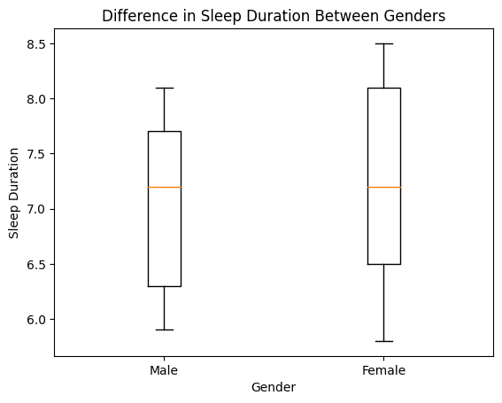

```python
# Define the two groups based on gender
males = df[df['Gender'] == 'Male']['Sleep Duration']
females = df[df['Gender'] == 'Female']['Sleep Duration']

# Perform the t-test for independent samples
t_statistic, p_value = stats.ttest_ind(males, females)

# Set the significance level
alpha = 0.05

# Print the results
print("Hypothesis 1: Difference in Sleep Duration Between Genders")
print("Null Hypothesis (H0): There is no significant difference in sleep duration between genders.")
print("Alternative Hypothesis (H1): There is a significant difference in sleep duration between genders.")
print()
print("Test Statistic:", t_statistic)
print("p-value:", p_value)
print()

# Check if the null hypothesis should be rejected
if p_value < alpha:
    print("Result: Reject the null hypothesis.")
    print("Conclusion: There is a significant difference in sleep duration between genders.")
else:
    print("Result: Fail to reject the null hypothesis.")
    print("Conclusion: There is no significant difference in sleep duration between genders.")

# Define the two groups based on gender
males = df[df['Gender'] == 'Male']['Sleep Duration']
females = df[df['Gender'] == 'Female']['Sleep Duration']

# Create a box plot
plt.boxplot([males, females], labels=['Male', 'Female'])
plt.title('Difference in Sleep Duration Between Genders')
plt.xlabel('Gender')
plt.ylabel('Sleep Duration')
plt.show()
```

## Hypothesis 2: Relationship Between Physical Activity Level and Sleep Quality

We want to explore the potential relationship between physical activity level and sleep quality. Specifically, we aim to determine whether individuals with higher physical activity levels tend to have better sleep quality scores. To test this hypothesis, we will use correlation analysis.

Null Hypothesis (H0): There is no significant correlation between physical activity level and sleep quality.  
Alternative Hypothesis (H1): There is a significant correlation between physical activity level and sleep quality.

We will calculate the correlation coefficient (e.g., Pearson's correlation coefficient) between physical activity level and sleep quality and assess its statistical significance. Additionally, we will provide a scatter plot to visualize the relationship between these variables.

The results of these hypothesis tests will help us draw conclusions about the differences in sleep duration between genders and the potential relationship between physical activity level and sleep quality in our dataset.

```
Hypothesis 2: Relationship Between Physical Activity Level and Sleep Quality
Null Hypothesis (H0): There is no significant correlation between physical activity level and sleep quality.
Alternative Hypothesis (H1): There is a significant correlation between physical activity level and sleep quality.

Correlation Coefficient: 0.19289645493975327
p-value: 0.0001745489524783864

Result: Reject the null hypothesis.
Conclusion: There is a significant correlation between physical activity level and sleep quality.
```

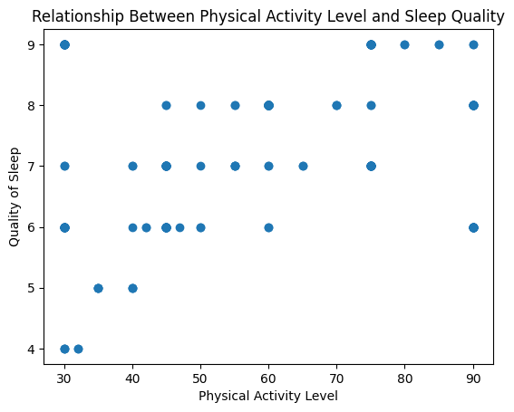

```python
# Calculate the correlation coefficient
correlation_coefficient, p_value = stats.pearsonr(df['Physical Activity Level'], df['Quality of Sleep'])

# Set the significance level
alpha = 0.05

# Print the results
print("Hypothesis 2: Relationship Between Physical Activity Level and Sleep Quality")
print("Null Hypothesis (H0): There is no significant correlation between physical activity level and sleep quality.")
print("Alternative Hypothesis (H1): There is a significant correlation between physical activity level and sleep quality.")
print()
print("Correlation Coefficient:", correlation_coefficient)
print("p-value:", p_value)
print()

# Check if the null hypothesis should be rejected
if p_value < alpha:
    print("Result: Reject the null hypothesis.")
    print("Conclusion: There is a significant correlation between physical activity level and sleep quality.")
else:
    print("Result: Fail to reject the null hypothesis.")
    print("Conclusion: There is no significant correlation between physical activity level and sleep quality.")

# Create a scatter plot
plt.scatter(df['Physical Activity Level'], df['Quality of Sleep'])
plt.title('Relationship Between Physical Activity Level and Sleep Quality')
plt.xlabel('Physical Activity Level')
plt.ylabel('Quality of Sleep')
plt.show()
```

# Conclusion

### Descriptive Statistics

We began our analysis by examining key descriptive statistics for the dataset. Notable findings include:

- **Sleep Duration:** The mean sleep duration for the individuals in our dataset is approximately 7.13 hours, with a median sleep duration of 7.2 hours. Sleep duration ranges from 5.8 to 8.5 hours, with a standard deviation of approximately 0.80 hours.
- **Age:** The mean age of the individuals is approximately 42.18 years, with a median age of 43 years. Age ranges from 27 to 59 years, with a standard deviation of approximately 8.67 years.
- **Heart Rate:** The mean resting heart rate is around 70.17 beats per minute (bpm), with a median of 70 bpm. Heart rates in the dataset range from 65 to 86 bpm, with a standard deviation of approximately 4.14 bpm.
- **Daily Steps:** The individuals take an average of 6816.84 daily steps, with a median of 7000 steps. Daily step counts range from 3000 to 10,000 steps, with a standard deviation of approximately 1617.92 steps.
- **Correlation:** The correlation between sleep duration and daily steps is -0.0395, indicating a weak negative correlation between these variables. Additionally, there is a strong positive correlation (correlation coefficient: 0.67) between stress level and heart rate, what is expected.

### Hypothesis Testing

#### Hypothesis 1: Difference in Sleep Duration Between Genders

We tested the hypothesis that there is a significant difference in sleep duration between genders. Our statistical analysis returned the following results:

- Test Statistic: -2.3624
- p-value: 0.0187 (rounded)

**Conclusion:** We reject the null hypothesis (H0) as the p-value is less than our predetermined significance level of 0.05. Therefore, there is a significant difference in sleep duration between genders.

#### Hypothesis 2: Relationship Between Physical Activity Level and Sleep Quality

We explored the hypothesis that there is a significant correlation between physical activity level and sleep quality. Our analysis resulted in the following findings:

- Correlation Coefficient: 0.1929
- p-value: 0.0002 (rounded)

**Conclusion:** We reject the null hypothesis (H0) as the p-value is less than our predetermined significance level of 0.05. Thus, there is a significant positive correlation between physical activity level and sleep quality. This suggests that individuals with higher physical activity levels tend to have better sleep quality scores.

### Overall Conclusion

In conclusion, our analysis provides valuable insights into the dataset. We have identified significant differences in sleep duration between genders and established a positive correlation between physical activity level and sleep quality. These findings have important implications for understanding factors that influence sleep patterns and overall well-being.